# Probability/Statistics on R

Aayush Kapoor

23 August 2019

# Task 1 Probability

##### Tossing a fair die 7 times. Consider the following events, A = “each value appears at least once” and B = “the outcome is alternate in numbers (i.e.,no two values are adjacent)”. What is p(A|B)?

```r
ntrials <- 100000 # total number of simulations we want to perform.
Bcounter <- 0 # a counter for checking whether B was true.
ABcounter <- 0 # a counter for checking intersection of A and B
for (i in 1:ntrials){
  dicethrow = sample(c(1,2,3,4,5,6),size = 7,replace = T)

  if (!(0 %in% diff(dicethrow))) # to check difference of adjecent dice throws are same.
    {
    Bcounter = Bcounter+1

    # the below condition to if A is true when B already happened.

    if(length(unique(dicethrow))==6) # to check all 6 numbers are present in dicethrow.
    {
      ABcounter = ABcounter+1
    }
  }
}

probAGB = ABcounter/Bcounter

probAGB # probability of A given B
```

```
## [1] 0.1170089
```

# Task 2 Imputation, Probability and Entropy

##### 2.1 Handle NAs by mode imputation, and plot individual variables in a histogram with proper axis labels and title.

```r
library(imputeMissings)
#The inbuilt library which can impute missing values based on 'mode' or 'RandomForest'. Unless specified specifically the method you want to use it computes mode value.(default='Mode')
q2data <- read.csv("Q2_data.csv")
q2data  # let's look at our data frame that currently has missing values.
```

| X | Y |
| --- | --- |
| 0 | 0 |
| 0 | 1 |
| 0 | 1 |
| 0 | 0 |
| 1 | 0 |
| 0 | 0 |
| 1 | 0 |
| 0 | 0 |
| NA | 0 |
| 1 | 1 |

[output cut: 90 more lines]

```r
q2data <- impute(q2data)
# Now let's look at our data frame after mode imputation.
q2data
```

| X | Y |
| --- | --- |
| 0 | 0 |
| 0 | 1 |
| 0 | 1 |
| 0 | 0 |
| 1 | 0 |
| 0 | 0 |
| 1 | 0 |
| 0 | 0 |
| 0 | 0 |
| 1 | 1 |

[output cut: 90 more lines]

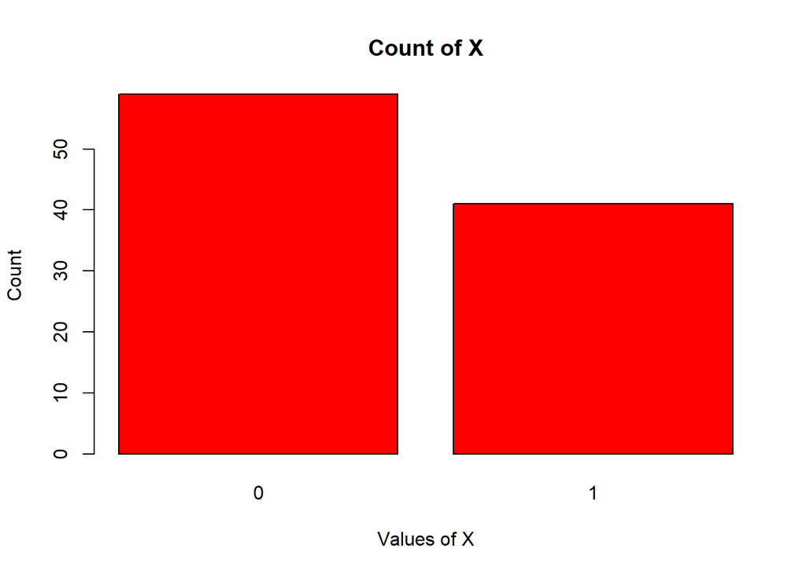

```r
# We need to create histograms for each variable.
# Let's create for variable X.
barplot(table(q2data$X),xlab = "Values of X", ylab = "Count",col='red',main ='Count of X')
```

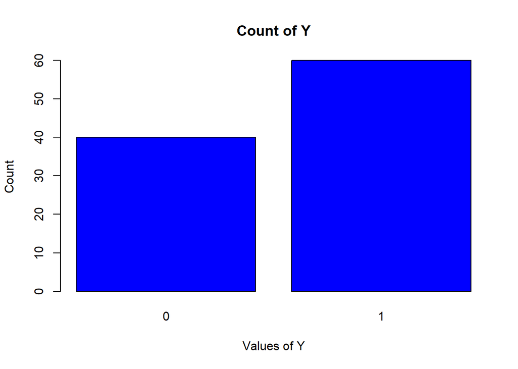

```r
# Let's create for variable Y.
barplot(table(q2data$Y),xlab = "Values of Y", ylab = "Count",col='blue',main ='Count of Y')
```

#### 2.2 Calculate and report full tables for p(X), p(Y), p(X,Y), p(X|Y),p(Y|X).

```r
# calculation probability of X
probX <- prop.table(table(q2data$X))
probX
```

```
##
##    0    1
## 0.59 0.41
```

```r
# calculation probability of Y
probY <- prop.table(table(q2data$Y))
probY
```

```
##
##   0   1
## 0.4 0.6
```

```r
# calculation probability of XY
probXY <- prop.table(table(q2data))
probXY
```

```
##    Y
## X      0    1
##   0 0.23 0.36
##   1 0.17 0.24
```

```r
# calculation probability of X given Y=1
probX_Y1 <- prop.table(table(q2data$X[q2data$Y==1]))
probX_Y1
```

```
##
##   0   1
## 0.6 0.4
```

```r
# calculation probability of X given Y=0
probX_Y0 <- prop.table(table(q2data$X[q2data$Y==0]))
probX_Y0
```

```
##
##     0     1
## 0.575 0.425
```

```r
# calculation probability of Y given X=1
probY_X1 <-prop.table(table(q2data$Y[q2data$X==1]))
probX_Y1
```

```
##
##   0   1
## 0.6 0.4
```

```r
# calculation probability of Y given X=0
probY_X0 <-prop.table(table(q2data$Y[q2data$X==0]))
probY_X0
```

```
##
##         0         1
## 0.3898305 0.6101695
```

```r
#
hX <- -sum(probX*log2(probX))
hX #entropy of X
```

```
## [1] 0.9765005
```

```r
hY <- -sum(probY*log2(probY))
hY #entropy of Y
```

```
## [1] 0.9709506
```

```r
hX_Y1 <- -sum(probX_Y1*log2(probX_Y1))
hX_Y1 #entropy of X given Y=1
```

```
## [1] 0.9709506
```

```r
hX_Y0 <- -sum(probX_Y0*log2(probX_Y0))
hX_Y0 #entropy of X given Y=0
```

```
## [1] 0.9837083
```

```r
hY_X1 <- -sum(probY_X1*log2(probY_X1))
hY_X1 #entropy of Y given X=1
```

```
## [1] 0.9788699
```

```r
hY_X0 <- -sum(probY_X0*log2(probY_X0))
hY_X0 #entropy of Y given X=0
```

```
## [1] 0.9646901
```

# Task 3 Covariance and Correlation

##### X and Y are standard normal variates thus X~N(0,1) and Y~N(0,1). Now, we have U and V random variable given by U = X-Y and V=2X+3Y. We need to find the covariance and correlation between U and V.

```r
set.seed(20) # changing the seed value.

X <- rnorm(1000000,0,1) # creating standard normal variables with mean 0 and variance 1

Y <- rnorm(1000000,0,1) # creating standard normal variables with mean 0 and variance 1

U <- X-Y       # Creating new random variable U(given) which depends on X and Y

V <- 2*X+3*Y   # Creating new random variable V(given) which depends on X and Y

cov(U,V) # to calculate covariance
```

```
## [1] -0.9996325
```

```r
cor(U,V) # to calculate correlation
```

```
## [1] -0.1957625
```

# Task 4 Maximum likelihood estimation

```r
# creating a new vector containing data obtained from poisson distribution.
datapoints <-c(4,3,2,4,6,3,4,0,5,6,4,4,4,5,3,3,4,5,4,5)

# creating a function that takes two arguments of which one is known and the other
# one we want to optimize. But, as we know the second derivative of Log likelihood of
# poisson distribution is -ve, lamda will maximize the given function.

func = function(lambda,datapoints)
{
  log_likelihood = sum(datapoints)*log(lambda)-(lambda)*length(datapoints)
}
optimize(func,c(min(datapoints),max(datapoints)),data=datapoints,maximum=TRUE)
```

```
## $maximum
## [1] 3.899999
##
## $objective
## [1] 28.15617
```

# Task 5 Central Limit Theorem

##### Consider sampling a sequence of 10 i.i.d. random variables from a Poisson distribution with lambda = 10. For this, experimentally justify the central limit theorem using simulation with sample size 100, 1000, 10000 and 100000.

```r
lambda <- 10
sample_size <- 10

# simulating 100 times
simulate100 <- vector()

for (i in 1:100) {

  simulate100 <- c(simulate100, mean (rpois(sample_size, lambda)))

  }

cat('The mean for 100 simulations:', mean(simulate100),'\n')
```

```
## The mean for 100 simulations: 10.011
```

```r
    #to display the sample mean
cat('The Standard deviation for 100 simulations:',sd(simulate100),'\n')
```

```
## The Standard deviation for 100 simulations: 0.9905508
```

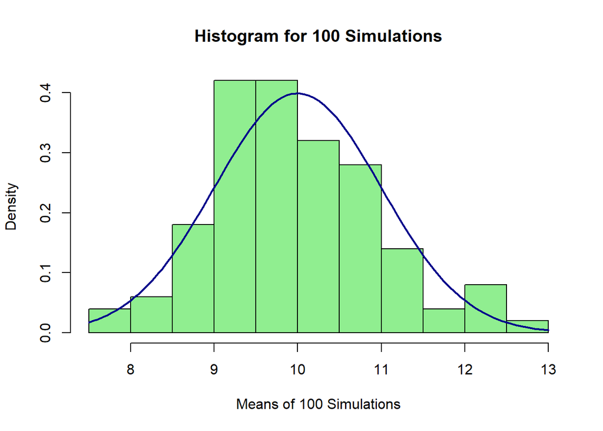

```r
#to display the standard deviation
hist(simulate100,col = "lightgreen",probability = TRUE,xlab = "Means of 100 Simulations",main = "Histogram for 100 Simulations")
curve(dnorm(x, mean=lambda, sd=1),col='darkblue',lwd=2,add = TRUE,yaxt = 'n')
```

```r
#creating normal theoretical curve to check how it fit's our simulation.


# simulating 1000 times
simulate1000 <- vector()

for (i in 1:1000) {

  simulate1000 <- c(simulate1000, mean (rpois(sample_size, lambda)))

  }

cat('The mean for 1000 simulations:', mean(simulate1000),'\n')
```

```
## The mean for 1000 simulations: 10.0051
```

```r
    #to display the sample mean
cat('The Standard deviation for 1000 simulations:',sd(simulate1000),'\n')
```

```
## The Standard deviation for 1000 simulations: 1.029195
```

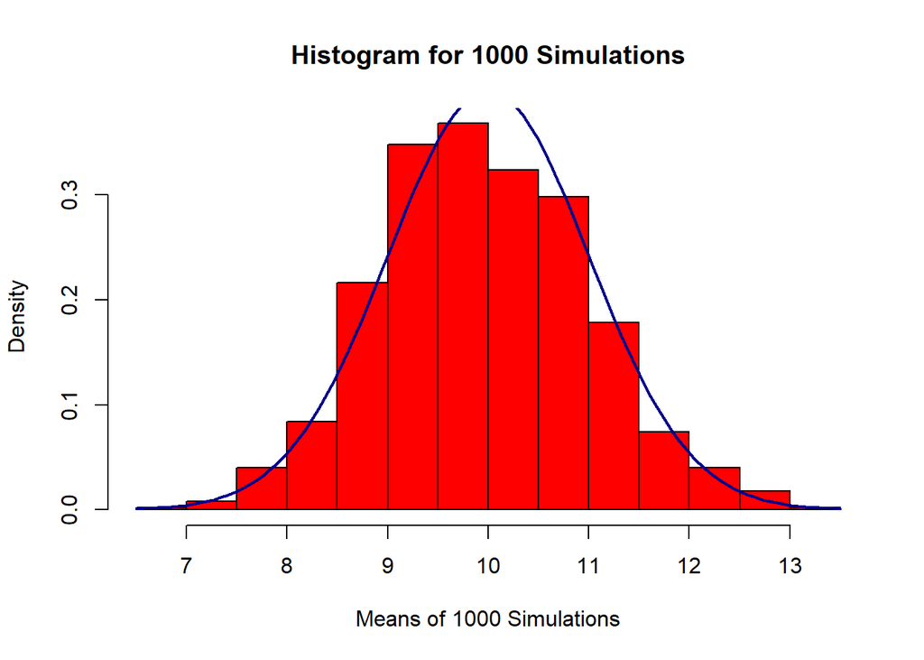

```r
#to display the standard deviation
hist(simulate1000,col = "red",probability = TRUE,xlab = "Means of 1000 Simulations",main = "Histogram for 1000 Simulations")
curve(dnorm(x, mean=lambda, sd=1),col='darkblue',lwd=2,add = TRUE,yaxt = 'n')
```